# Using Bayesian Logistic Regression to Predict Outcomes of Denver Nuggets Games

Cameron Stivers

2023-03-13

## Research Topic

In this report, I will be doing a Bayesian logistic regression analysis predicting the outcome of games played by the Denver Nuggets, a team in the NBA. In particular, the predictor variables that I will be looking at are whether the game is played at home or away, whether the opponent is from the Western or Eastern Conference, the opponent’s current win percentage, and their “net points per game” (the difference between points scored and points given up per game).

## Setting Priors

beta1: Home/away beta2: Opponent Conference beta3: Opp. Win Percent beta4: Opp. Net Points Per Game (Points Per Game - Points Given Up Per Game)

My criteria for the prior distributions were somewhat loose. Each of them follow a normal distribution. For $\beta_0$, my knowledge of the recent Denver Nuggets teams tells me that in an average game, they should have a more than 50% chance of victory, given that they’ve consistently been a playoff team over the last few years. I chose an average of about 60%, which would lead to a log(odds) of about 0.4, which I raised to 0.6 in my prior distribution to account for opposing teams almost certainly having a win percentage above 0, and thus decreasing (according to my prior belief) the chance of victory. For the others, I chose mostly positive values for $\beta_1$, as I believe being the home team does raise a team’s chance of victory, but not by much. For $\beta_2$, I don’t believe the conference of the opponent has much of an effect on the chance of victory, and I am also uncertain about what the direction of influence would be, so I centered it at 0. $\beta_3$ and $\beta_4$ are each mostly negative because I expect stronger opponents to reduce the chance of victory for the Nuggets. Small adjustments were made until I reached a satisfying prior predictive distribution.

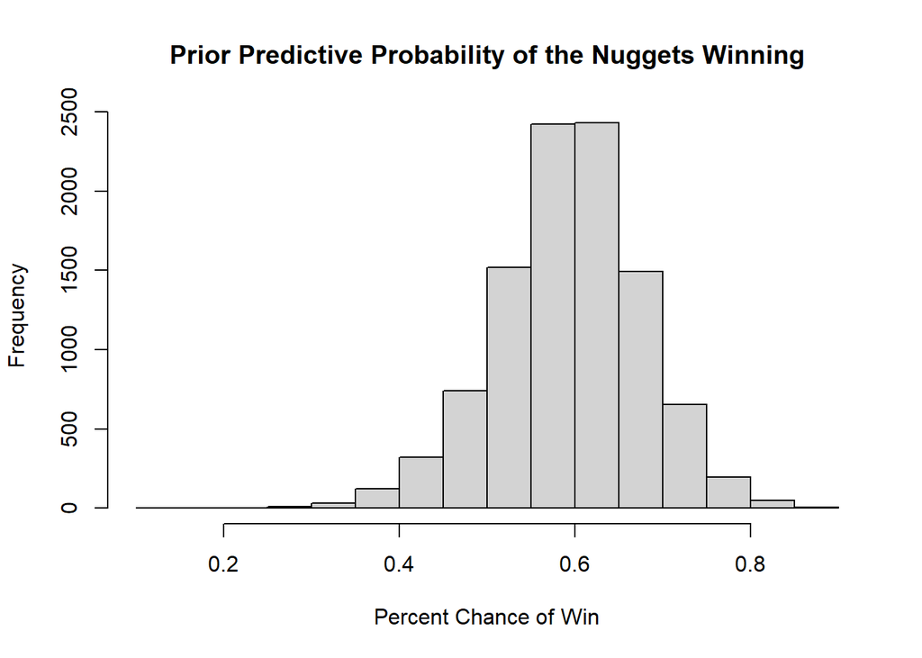

```r
# Prior distributions and predictions after tuning
n_reps = 10000

beta0 = rnorm(n_reps, 0.6, 0.1)

beta1 = rnorm(n_reps, 0.08, 0.04)

beta2 = rnorm(n_reps, 0, 0.05)

beta3 = rnorm(n_reps, -0.5, 0.2)

beta4 = rnorm(n_reps, -0.1, 0.04)

x1 = rbinom(n_reps, 1, 0.5) # simulating if a game is at home
x2 = rbinom(n_reps, 1, 30 / 82) # simulating whether a game is played against an eastern opponent
x3 = rnorm(n_reps, 0.5, 0.12) # simulating opponent win percentages
x4 = rnorm(n_reps, 0, 3) # simulating  opponent net points per game

y = (exp(beta0 + beta1*x1 + beta2*x2 + beta3*x3 + beta4*x4)) / (1 + exp(beta0 + beta1*x1 + beta2*x2 + beta3*x3 + beta4*x4))

outcome = rbinom(n_reps, 1, y)

prior = data.frame(beta0, beta1, beta2, beta3, beta4, x1, x2, x3, x4, y, outcome)
hist(prior$y, xlab = "Percent Chance of Win", main = "Prior Predictive Probability of the Nuggets Winning")
```

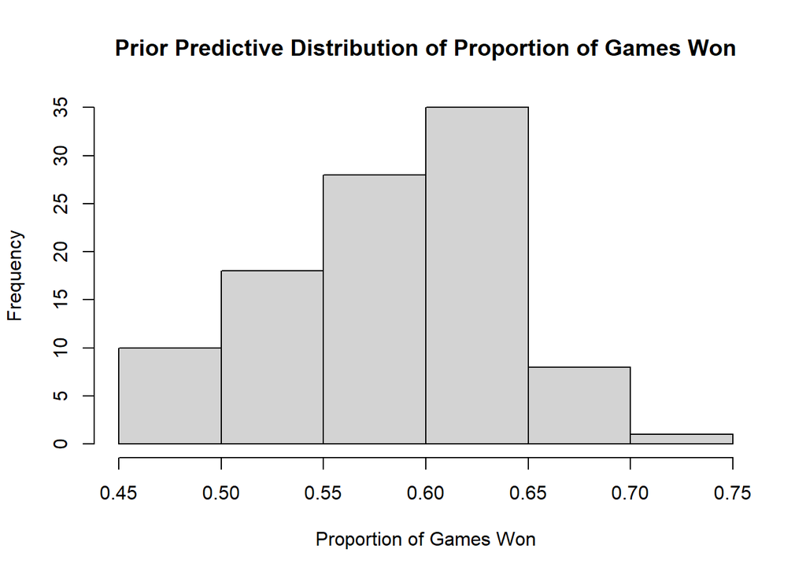

```r
# Simulating win proportions in 100 game samples
win_prop = c()
for (n in 1:100){
  total_wins = 0
  for (m in (1+(100*(n-1))):(100*n)){
    total_wins = outcome[m] + total_wins
  }
  win_prop[n] = total_wins / 100
}
hist(win_prop, xlab = "Proportion of Games Won", main = "Prior Predictive Distribution of Proportion of Games Won")
```

## The Data

The data below is sourced from basketball-reference.com. The sample used is Denver Nugget’s games over the past 2 seasons (150 games in total, playoffs not included). Because the sample is from the last 2 seasons, it safely represents the population of Nuggets regular season games, as all teams in the NBA are represented more than once in both home and away games.

```r
nuggets_scores <- read.table("nuggetsgames.csv", sep = ",", header = TRUE, fileEncoding = "UTF-8-BOM")
```

```r
nuggets_scores <- nuggets_scores |>
  mutate(ONetPPG = OPPG - ODPPG)
nuggets_scores |>
  tail(10)
```

```
##     Result Home    WP OppWP Oconference  OPPG ODPPG ONetPPG
## 141      1    1 0.583 0.493           0 108.4 108.4     0.0
## 142      0    1 0.589 0.808           0 114.8 107.3     7.5
## 143      1    1 0.581 0.288           0 103.7 111.8    -8.1
## 144      1    0 0.587 0.520           1 115.3 114.9     0.4
## 145      1    0 0.592 0.329           1 111.5 114.9    -3.4
## 146      0    1 0.597 0.558           0 115.9 113.3     2.6
## 147      1    0 0.590 0.403           0 112.1 115.1    -3.0
## 148      0    1 0.595 0.423           0 113.2 113.0     0.2
## 149      1    1 0.588 0.696           0 115.6 109.9     5.7
## 150      0    1 0.593 0.395           0 112.1 115.1    -3.0
```

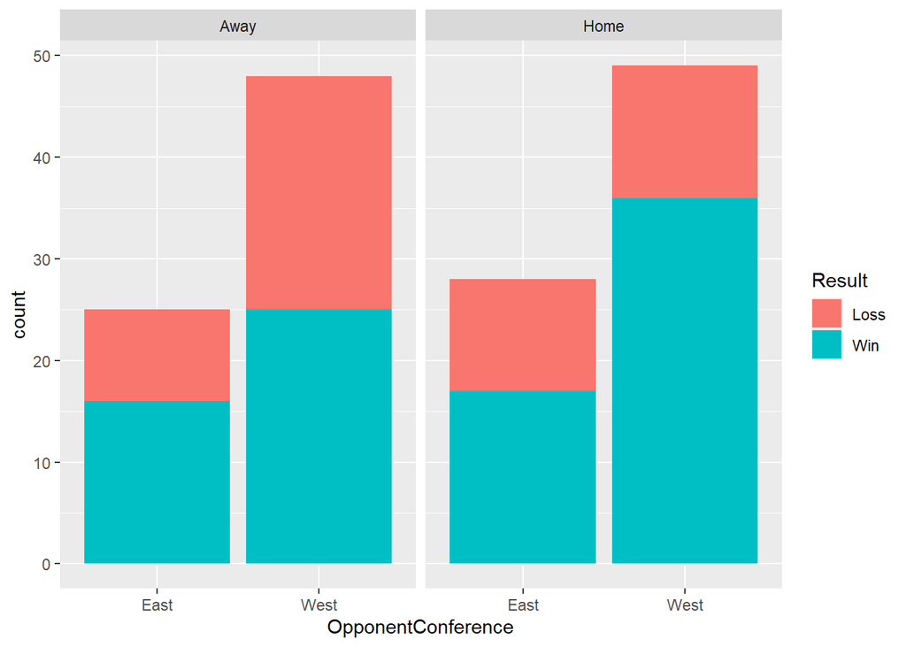

```r
nuggets_scores |>
  mutate(Result = ifelse(Result == 1, "Win", "Loss"),
         Home = ifelse(Home == 1, "Home", "Away"),
         OpponentConference = ifelse(Oconference == 1, "East", "West")) |>
  ggplot(aes(x = OpponentConference, fill = Result)) +
    geom_bar() +
  facet_wrap(~Home)
```

Generally, more games are won at home than away against Western teams, but otherwise, there isn’t much of a relationship to be seen above.

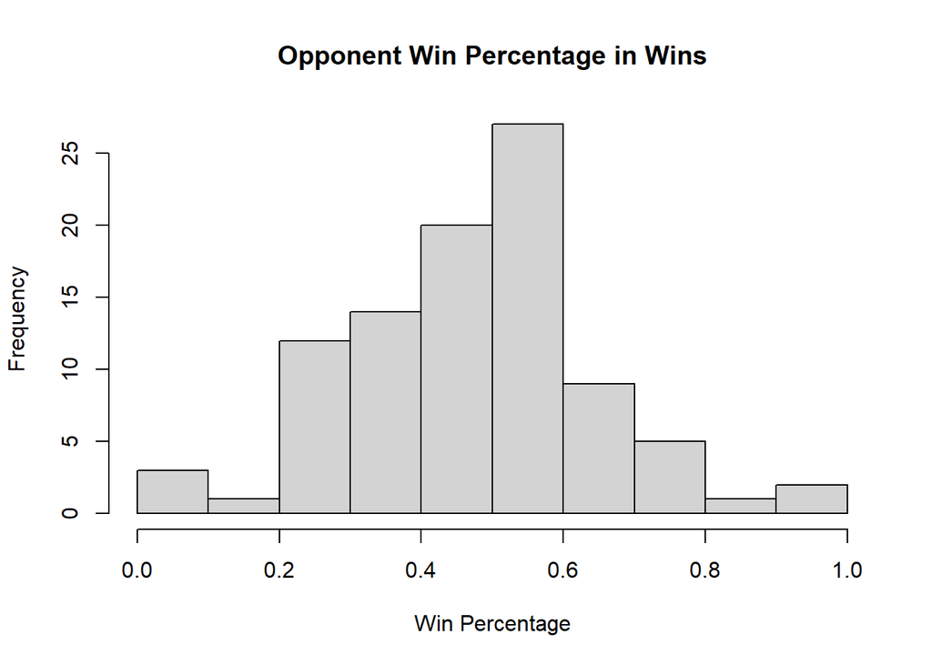

```r
nuggets_wins <- nuggets_scores |>
  filter(Result == 1)
nuggets_losses <- nuggets_scores |>
  filter(Result == 0)
hist(nuggets_wins$OppWP, xlab = "Win Percentage", main = "Opponent Win Percentage in Wins")
```

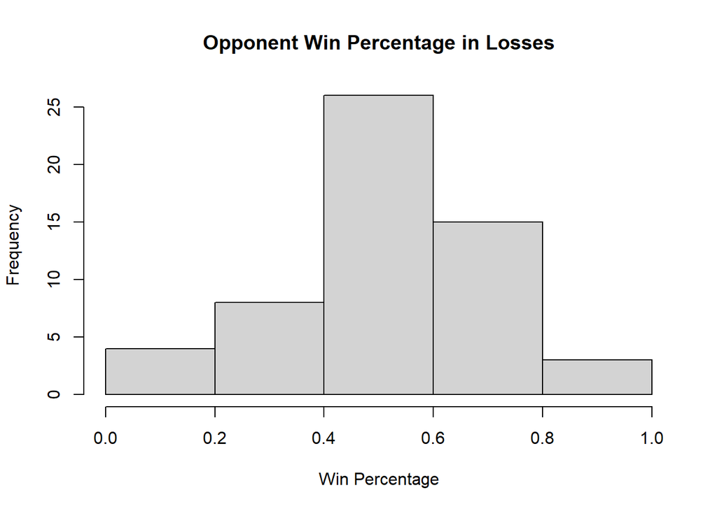

```r
hist(nuggets_losses$OppWP, xlab = "Win Percentage", main = "Opponent Win Percentage in Losses")
```

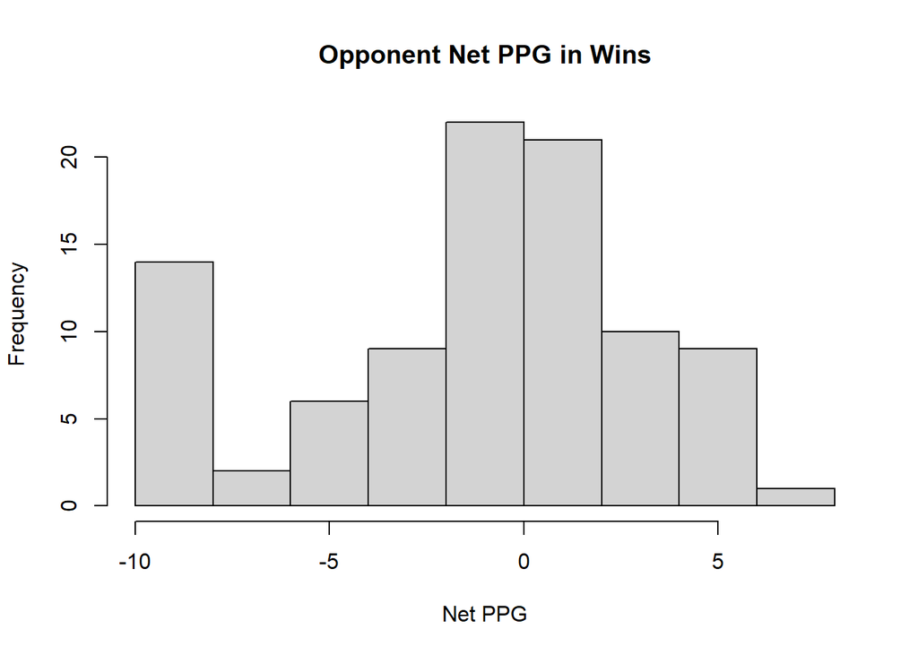

```r
hist(nuggets_wins$ONetPPG, xlab = "Net PPG", main = "Opponent Net PPG in Wins")
```

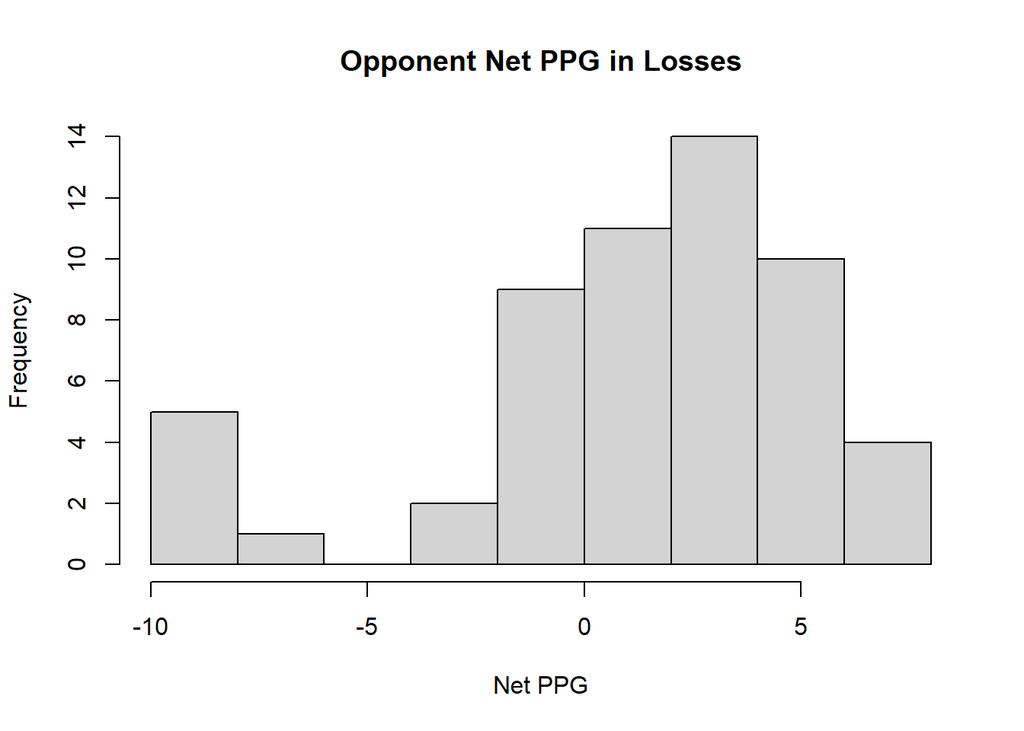

```r
hist(nuggets_losses$ONetPPG, xlab = "Net PPG", main = "Opponent Net PPG in Losses")
```

In Nuggets wins, a slightly larger proportion of their opponents’ win percentages are low than in losses, which makes sense because we expect more wins to come against teams that have lost more often. Where this pattern is more evident is in the opponents’ net points per game, as there is a clear shift in the distribution of opponent net points per game between wins and losses. In wins, more opposing teams have a negative net points per game, and in losses, more teams have a positive net points per game, which also makes sense because net points per game is indicative of the opponent’s strength.

## Posterior

```r
prior_intercept <- set_prior("normal(0.4,0.1)", class = "Intercept")
prior1 <- set_prior("normal(0.08,0.04)", class = "b", coef = "Home")
prior2 <- set_prior("normal(0,0.05)", class = "b", coef = "Oconference")
prior3 <- set_prior("normal(-0.5,0.2)", class = "b", coef = "OppWP")
prior4 <- set_prior("normal(-0.1,0.04)", class = "b", coef = "ONetPPG")
```

Fitting the logistic regression model using these prior distributions:

```r
fit <- brm(data = nuggets_scores,
           family = bernoulli(),
           Result ~ Home + Oconference + OppWP + ONetPPG,
           prior = c(prior_intercept,prior1,prior2,prior3,prior4),
           iter = 3500,
           warmup = 1000,
           chains = 4,
           refresh = 0)
summary(fit)
```

```
##  Family: bernoulli
##   Links: mu = logit
## Formula: Result ~ Home + Oconference + OppWP + ONetPPG
##    Data: nuggets_scores (Number of observations: 150)
##   Draws: 4 chains, each with iter = 3500; warmup = 1000; thin = 1;
##          total post-warmup draws = 10000
##
## Regression Coefficients:
##             Estimate Est.Error l-95% CI u-95% CI Rhat Bulk_ESS Tail_ESS
## Intercept       0.61      0.13     0.35     0.86 1.00    13211     8252
## Home            0.09      0.04     0.01     0.16 1.00    13671     8173
## Oconference     0.00      0.05    -0.10     0.10 1.00    12861     7214
## OppWP          -0.48      0.19    -0.86    -0.10 1.00    13334     8446
## ONetPPG        -0.11      0.03    -0.17    -0.05 1.00    13660     7577
##
## Draws were sampled using sampling(NUTS). For each parameter, Bulk_ESS
## and Tail_ESS are effective sample size measures, and Rhat is the potential
## scale reduction factor on split chains (at convergence, Rhat = 1).
```

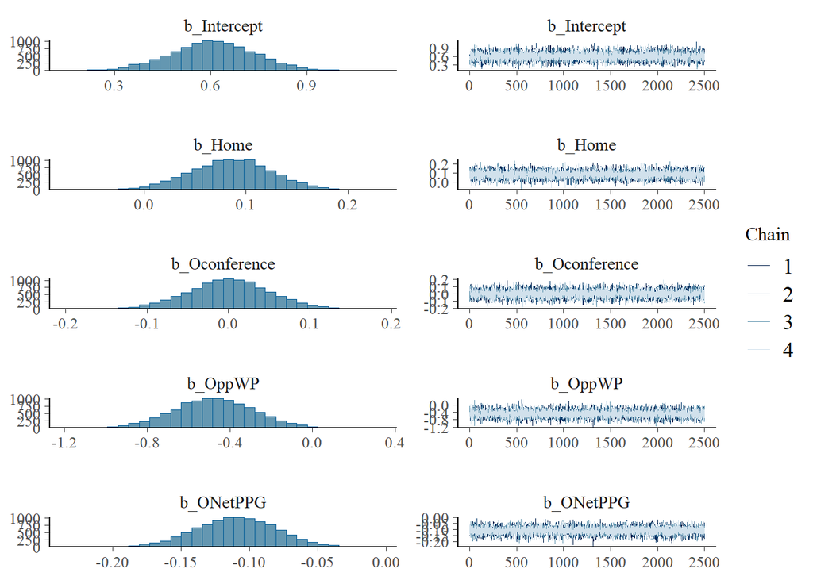

```r
plot(fit)
```

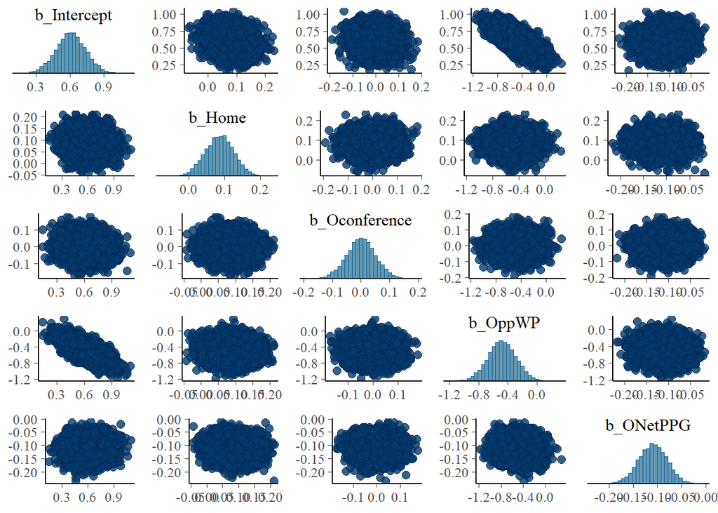

```r
pairs(fit)
```

A lot of the parameters look uninformative and have a lot of uncertainty, shown by their large spread, specifically the intercept. There is strong correlation between the intercept and win percentage, which makes sense because a win percentage must always be at least 0, so a change in the intercept is correlated with a change in $\beta_3$. Centering $\beta_3$, along with $\beta_1$ and $\beta_2$ should get rid of any correlation with the intercept.

```r
nuggets_scores <- nuggets_scores |>
  mutate(OppWP = OppWP - mean(OppWP)) |>
  mutate(Home = Home - 0.5) |>
  mutate(Oconference = Oconference - 0.5)
fit_centered <- brm(data = nuggets_scores,
           family = bernoulli(),
           Result ~ Home + Oconference + OppWP + ONetPPG,
           prior = c(prior_intercept,prior1,prior2,prior3,prior4),
           iter = 3500,
           warmup = 1000,
           chains = 4,
           refresh = 0)
summary(fit_centered)
```

```
##  Family: bernoulli
##   Links: mu = logit
## Formula: Result ~ Home + Oconference + OppWP + ONetPPG
##    Data: nuggets_scores (Number of observations: 150)
##   Draws: 4 chains, each with iter = 3500; warmup = 1000; thin = 1;
##          total post-warmup draws = 10000
##
## Regression Coefficients:
##             Estimate Est.Error l-95% CI u-95% CI Rhat Bulk_ESS Tail_ESS
## Intercept       0.41      0.09     0.24     0.58 1.00    12472     8167
## Home            0.08      0.04     0.01     0.16 1.00    13018     7706
## Oconference     0.00      0.05    -0.10     0.10 1.00    11809     8096
## OppWP          -0.48      0.20    -0.86    -0.10 1.00    11325     7918
## ONetPPG        -0.11      0.03    -0.17    -0.05 1.00    12676     8333
##
## Draws were sampled using sampling(NUTS). For each parameter, Bulk_ESS
## and Tail_ESS are effective sample size measures, and Rhat is the potential
## scale reduction factor on split chains (at convergence, Rhat = 1).
```

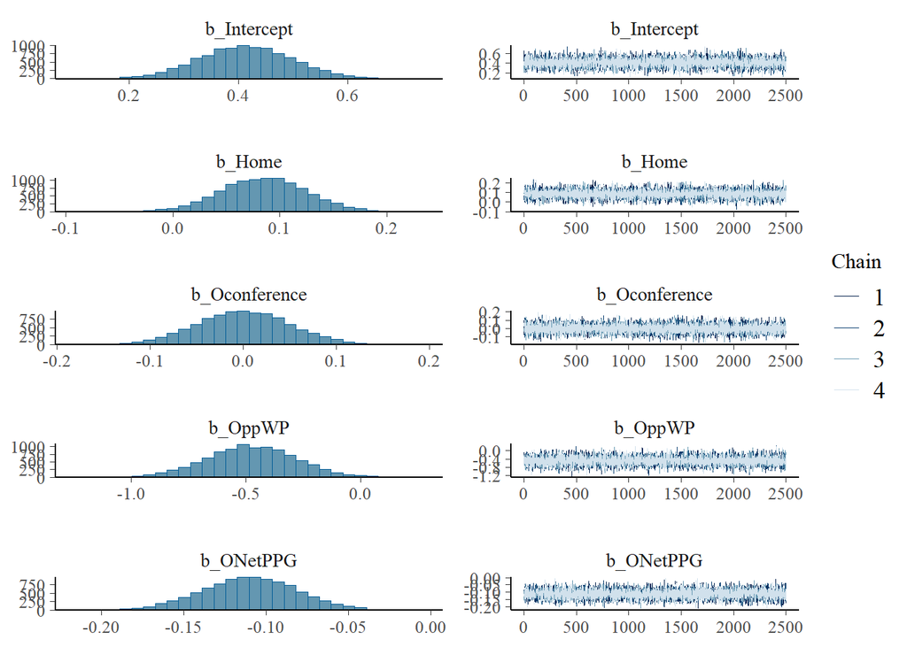

```r
plot(fit_centered)
```

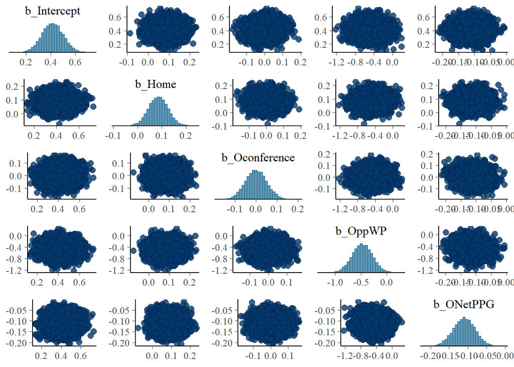

```r
pairs(fit_centered)
```

This model looks a lot better, as now there is no longer any correlation between parameters.

## Analysis and Conclusions

```r
posterior = fit_centered |>
  spread_draws(b_Intercept, b_Home, b_Oconference, b_OppWP, b_ONetPPG)
posterior |>
  head(5) |>
  kbl() |>
  kable_styling()
```

| .chain | .iteration | .draw | b_Intercept | b_Home | b_Oconference | b_OppWP | b_ONetPPG |
| --- | --- | --- | --- | --- | --- | --- | --- |
| 1 | 1 | 1 | 0.6517801 | 0.1116336 | 0.0941921 | -0.6045744 | -0.0990543 |
| 1 | 2 | 2 | 0.3713916 | 0.0892817 | -0.0751925 | -0.0797424 | -0.1231843 |
| 1 | 3 | 3 | 0.3050538 | 0.0773082 | -0.0015627 | -0.6814096 | -0.0609238 |
| 1 | 4 | 4 | 0.4962350 | 0.1069573 | -0.0225949 | -0.3149241 | -0.1394135 |
| 1 | 5 | 5 | 0.4522101 | 0.0154798 | -0.0248619 | -0.4920857 | -0.1067107 |

```r
quantile(posterior$b_Intercept, c(0.1, 0.9))
```

```
##       10%       90%
## 0.3021998 0.5231862
```

```r
quantile(posterior$b_Home, c(0.1, 0.9))
```

```
##        10%        90%
## 0.03367505 0.13593598
```

```r
quantile(posterior$b_Oconference, c(0.1, 0.9))
```

```
##         10%         90%
## -0.06358971  0.06470545
```

```r
quantile(posterior$b_OppWP, c(0.1, 0.9))
```

```
##        10%        90%
## -0.7287051 -0.2265929
```

```r
quantile(posterior$b_ONetPPG, c(0.1, 0.9))
```

```
##         10%         90%
## -0.14755855 -0.07342691
```

```r
n_rep = length(posterior$b_Intercept)

posterior <- posterior |>
  mutate(x1 = rbinom(n_reps, 1, 0.5)) |>
  mutate(x2 = rbinom(n_reps, 1, 30/82)) |>
  mutate(x3 = rnorm(n_reps, 0, 0.12)) |>
  mutate(x4 = rnorm(n_reps, 0, 3))
```

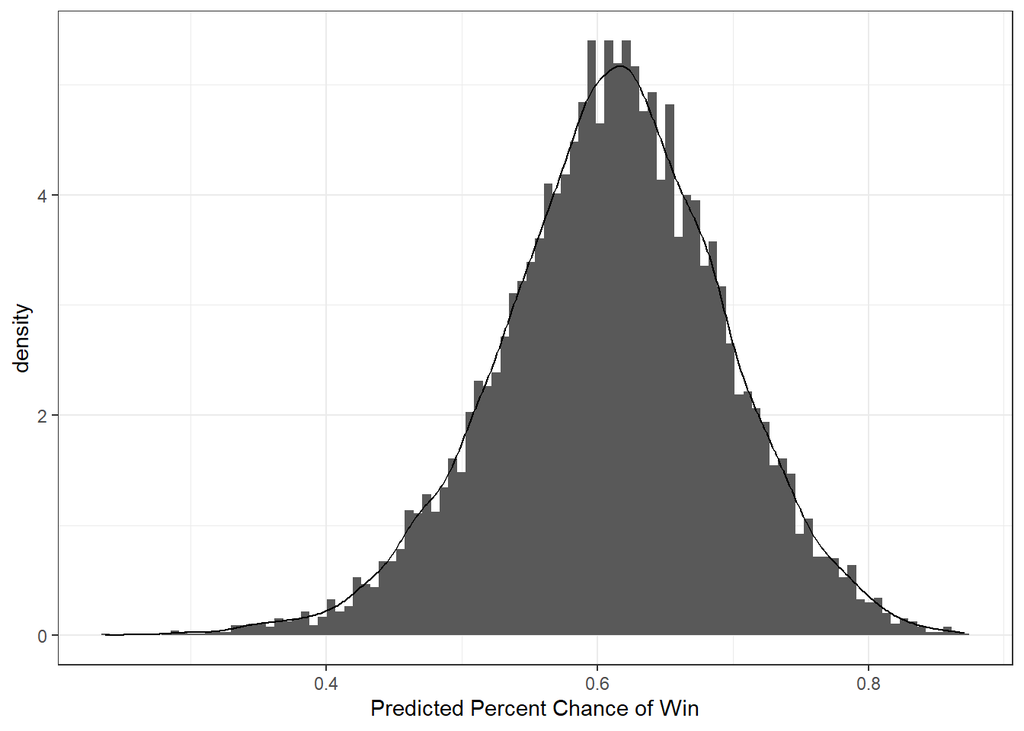

```r
posterior <- posterior |>
  mutate(y_predict = (exp(b_Intercept + b_Home*x1 + b_Oconference*x2 + b_OppWP*x3 + b_ONetPPG*x4)) / (1 + exp(b_Intercept + b_Home*x1 + b_Oconference*x2 + b_OppWP*x3 + b_ONetPPG*x4)))

ggplot(posterior,
       aes(x = y_predict)) +
  geom_histogram(aes(y = after_stat(density)), bins = 100) +
  geom_density() +
  labs(x = "Predicted Percent Chance of Win") +
  theme_bw()
```

```r
quantile(posterior$y_predict, c(0.1, 0.5, 0.9))
```

```
##       10%       50%       90%
## 0.5041353 0.6130666 0.7146244
```

In any game, there is an 80% chance that the Nuggets have between a 50.3% and 71.4% chance of victory based on the posterior predictive distribution.

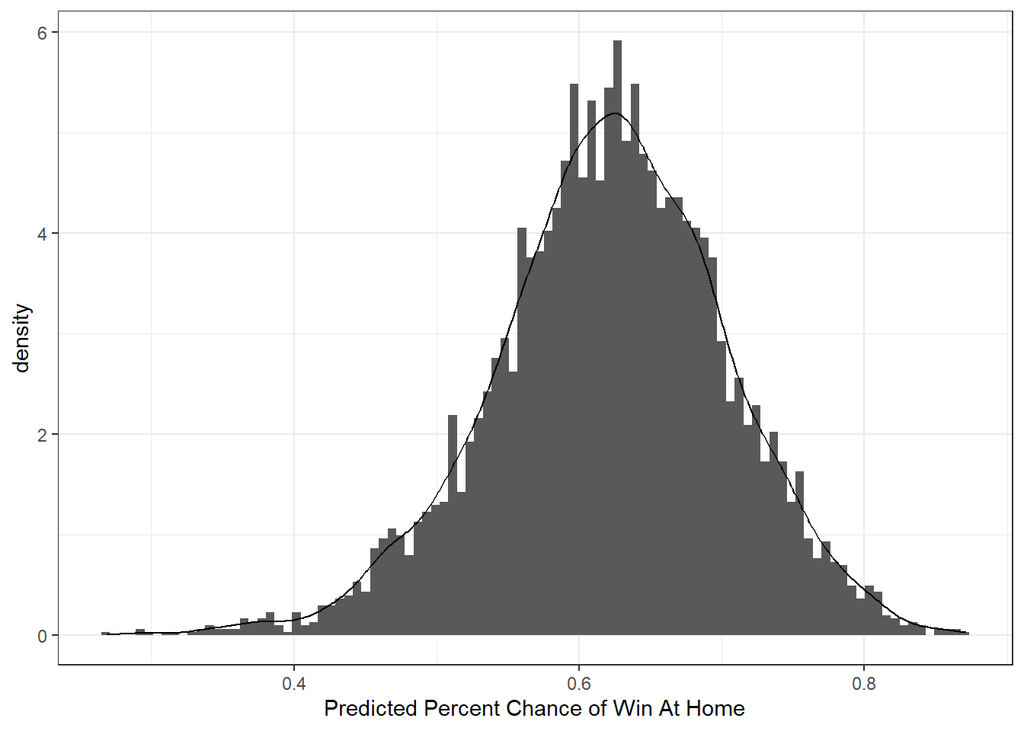

```r
posterior_home <- posterior |>
  filter(x1 == 1)
ggplot(posterior_home,
       aes(x = y_predict)) +
  geom_histogram(aes(y = after_stat(density)), bins = 100) +
  geom_density() +
  labs(x = "Predicted Percent Chance of Win At Home") +
  theme_bw()
```

```r
quantile(posterior_home$y_predict, c(0.1, 0.5, 0.9))
```

```
##       10%       50%       90%
## 0.5158930 0.6235907 0.7238947
```

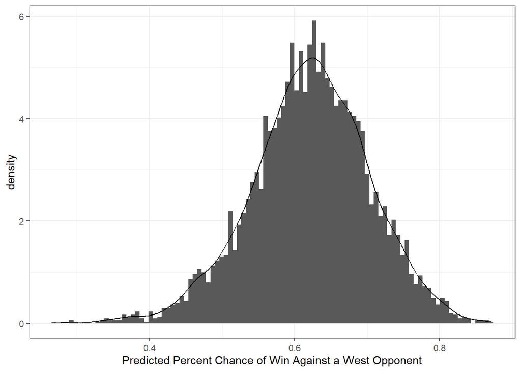

```r
posterior_west <- posterior |>
  filter(x2 == 0)
ggplot(posterior_home,
       aes(x = y_predict)) +
  geom_histogram(aes(y = after_stat(density)), bins = 100) +
  geom_density() +
  labs(x = "Predicted Percent Chance of Win Against a West Opponent") +
  theme_bw()
```

```r
quantile(posterior_west$y_predict, c(0.1,0.5,0.9))
```

```
##       10%       50%       90%
## 0.5034521 0.6117868 0.7136249
```

In any game against a Western opponent, there is an 80% chance that the Nuggets have between a 50.2% and 71.2% chance of victory.

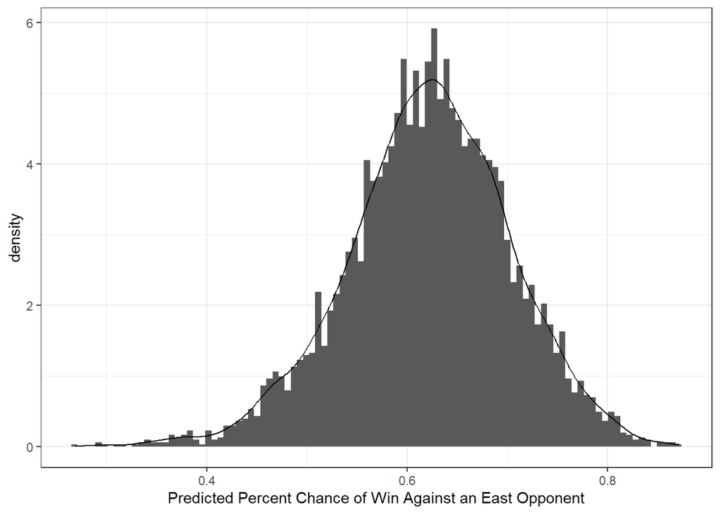

```r
posterior_east <- posterior |>
  filter(x2 == 1)
ggplot(posterior_home,
       aes(x = y_predict)) +
  geom_histogram(aes(y = after_stat(density)), bins = 100) +
  geom_density() +
  labs(x = "Predicted Percent Chance of Win Against an East Opponent") +
  theme_bw()
```

```r
quantile(posterior_east$y_predict, c(0.1,0.5,0.9))
```

```
##       10%       50%       90%
## 0.5058228 0.6146452 0.7158255
```

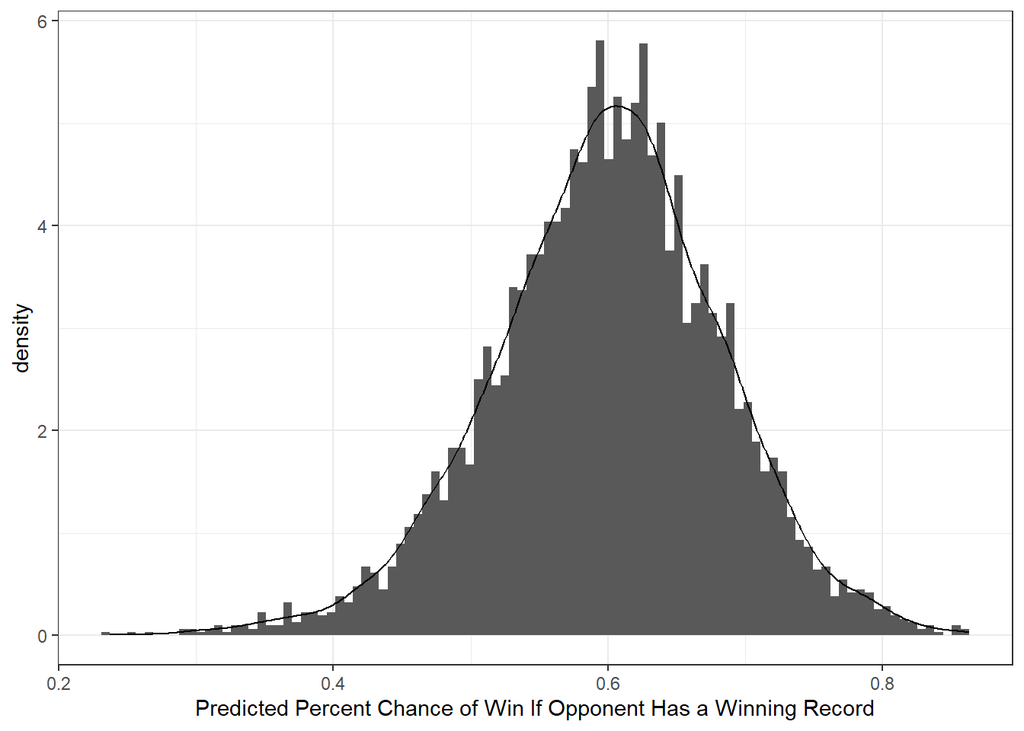

```r
posterior_wp1 <- posterior |>
  filter(x3 >= 0)
ggplot(posterior_wp1,
       aes(x = y_predict)) +
  geom_histogram(aes(y = after_stat(density)), bins = 100) +
  geom_density() +
  labs(x = "Predicted Percent Chance of Win If Opponent Has a Winning Record") +
  theme_bw()
```

```r
quantile(posterior_wp1$y_predict, c(0.1,0.5,0.9))
```

```
##       10%       50%       90%
## 0.4921901 0.6018772 0.7020274
```

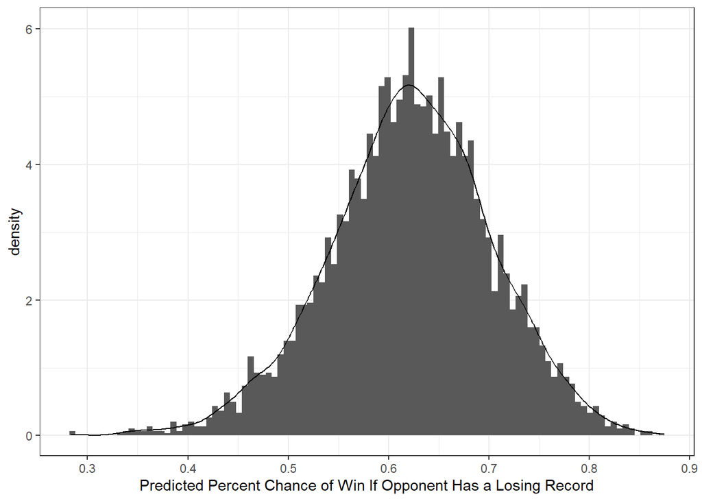

```r
posterior_wp2 <- posterior |>
  filter(x3 < 0)
ggplot(posterior_wp2,
       aes(x = y_predict)) +
  geom_histogram(aes(y = after_stat(density)), bins = 100) +
  geom_density() +
  labs(x = "Predicted Percent Chance of Win If Opponent Has a Losing Record") +
  theme_bw()
```

```r
quantile(posterior_wp2$y_predict, c(0.1,0.5,0.9))
```

```
##       10%       50%       90%
## 0.5174460 0.6231496 0.7250698
```

If the opponent has a losing record, then there is an 80% chance that the Nuggets have between a 51.6% and 72% chance of victory. There is a very slight trend here, but nothing noticeable.

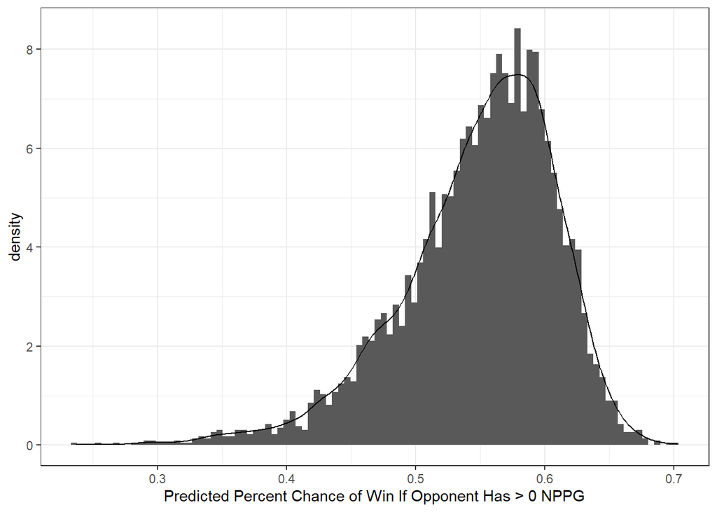

```r
posterior_nppg1 <- posterior |>
  filter(x4 >= 0)
ggplot(posterior_nppg1,
       aes(x = y_predict)) +
  geom_histogram(aes(y = after_stat(density)), bins = 100) +
  geom_density() +
  labs(x = "Predicted Percent Chance of Win If Opponent Has > 0 NPPG") +
  theme_bw()
```

```r
quantile(posterior_nppg1$y_predict, c(0.1, 0.5, 0.9))
```

```
##       10%       50%       90%
## 0.4679932 0.5586051 0.6164318
```

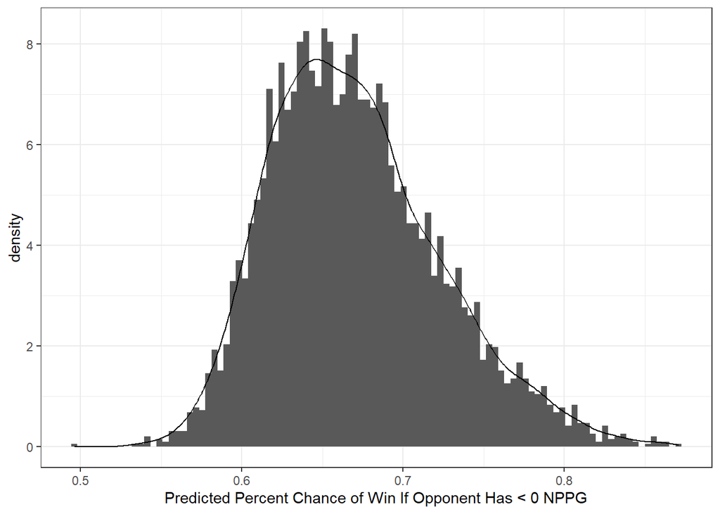

```r
posterior_nppg2 <- posterior |>
  filter(x4 < 0)
ggplot(posterior_nppg2,
       aes(x = y_predict)) +
  geom_histogram(aes(y = after_stat(density)), bins = 100) +
  geom_density() +
  labs(x = "Predicted Percent Chance of Win If Opponent Has < 0 NPPG") +
  theme_bw()
```

```r
quantile(posterior_nppg2$y_predict, c(0.1, 0.5, 0.9))
```

```
##       10%       50%       90%
## 0.6084179 0.6648337 0.7428899
```

Some general conclusions: In most games, the Nuggets are more likely to win than than lose based on the posterior distribution, with a mean chance of victory of about 61.1%. Being the home team only barely increases their chance of victory (the interval only goes up by about 1 percent). Whether the opponent is from the East or West has basically no influence on the Nuggets’ odds of winning the game. Surprisingly, the opponent’s record has hardly any influence, but in hindsight, it makes some sense because early in the season, a lot of teams have either a perfect record or a winless record. The biggest influence on their chance of victory is the net points per game of their opponent. These results are mostly expected and make sense, as the Nuggets were a playoff team last season and are on track to be the top Western Conference team this year, so it should be expected that they have a higher chance of victory in most games, and that their chances are lower if the opposing team is stronger than others.

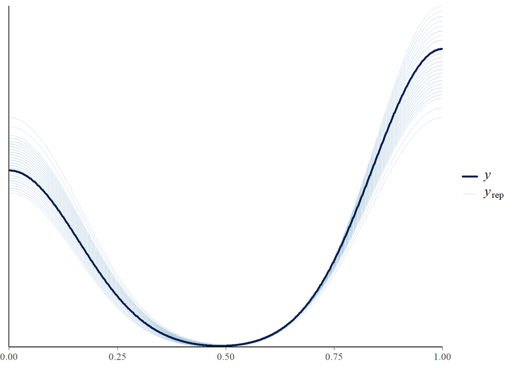

```r
pp_check(fit, ndraws = 100)
```

The posterior predictive check suggests that we have a suitable model.

## What if BRMS Chooses the Priors?

```r
fit_noprior <- brm(data = nuggets_scores,
           family = bernoulli(),
           Result ~ Home + Oconference + OppWP + ONetPPG,
           iter = 3500,
           warmup = 1000,
           chains = 4,
           refresh = 0)
```

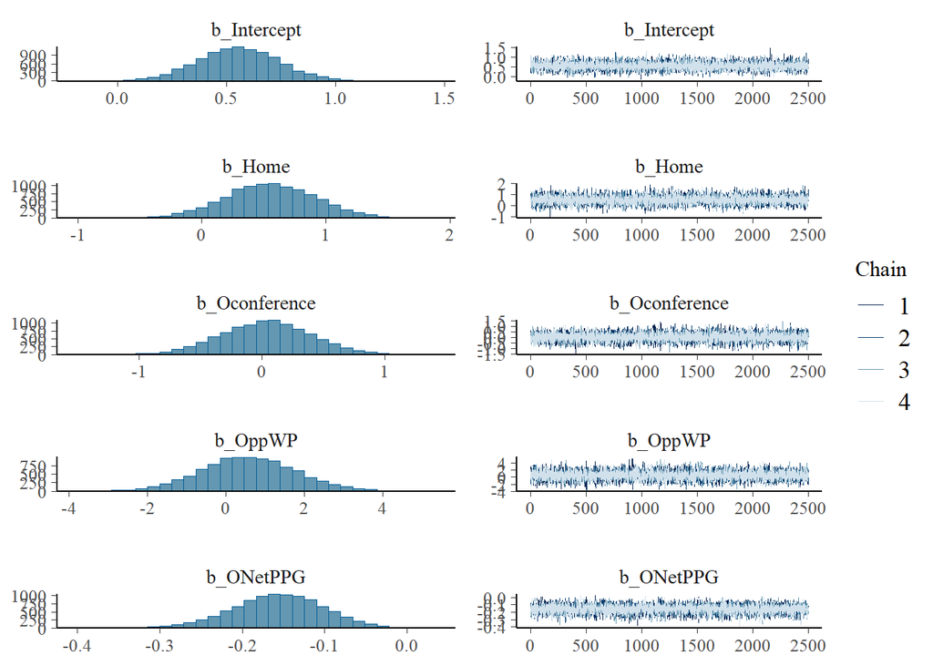

```r
plot(fit_noprior)
```

Noticeably, the posterior distributions when prior distributions are not given suggest more uncertainty, given that the spread is larger for each of them. This implies that the posterior distribution is noticeably sensitive to the prior distributions that we come up with. Also, we still see that opponent net points per game is still influential to win chance, as the distribution above suggests with a lot of certainty that the relationship is negative. With a variable like home or away, we can see that the previous model was likely influenced by the prior belief that being the home team has little, but a positive, influence on win chance, but here, it is evident that there is less certainty on how strong that influence is, despite it showing a positive one.

Should there have been more data, these distributions would likely have shown more certainty and less spread, but the trade-off of that is once we start adding more games from years past, we start to include games from versions of the Nuggets that become less and less similar to the current team. Since we are concerned about the chance of the team winning future games, it is best to use data that is most relevant to the current team, which means the prior distributions we use are influential to the posterior distributions and are very important to consider beforehand.

## Frequentist Analysis

The code below was used from: https://www.r-bloggers.com/2015/09/how-to-perform-a-logistic-regression-in-r/

```r
freq_model <- glm(formula = Result ~ Home + Oconference + OppWP + ONetPPG, family = binomial(link = "logit"), data = nuggets_scores)
```

```r
summary(freq_model)
```

```
##
## Call:
## glm(formula = Result ~ Home + Oconference + OppWP + ONetPPG,
##     family = binomial(link = "logit"), data = nuggets_scores)
##
## Coefficients:
##             Estimate Std. Error z value Pr(>|z|)
## (Intercept)  0.53896    0.18554   2.905  0.00367 **
## Home         0.52968    0.35360   1.498  0.13415
## Oconference  0.02857    0.36812   0.078  0.93813
## OppWP        0.51298    1.15455   0.444  0.65681
## ONetPPG     -0.14879    0.05301  -2.807  0.00500 **
## ---
## Signif. codes:  0 '***' 0.001 '**' 0.01 '*' 0.05 '.' 0.1 ' ' 1
##
## (Dispersion parameter for binomial family taken to be 1)
##
##     Null deviance: 198.21  on 149  degrees of freedom
## Residual deviance: 184.65  on 145  degrees of freedom
## AIC: 194.65
##
## Number of Fisher Scoring iterations: 4
```

The results from the frequentist analysis show that $\beta_0$ and $\beta_4$ are statistically significant (assuming an $\alpha$ of 0.05). $\beta_1$, $\beta_2$, and $\beta_3$ are all not statistically significant, meaning there is not enough evidence that being the home or away team, the conference of the opponent, and the opponent’s win percentage are associated with the Nuggets’ chance of winning the game. These are consistent with the Bayesian analysis, as we only saw opponent net points per game have any noticeable effect on the posterior predictive distribution when controlling for the other variables.